# Final Activity

## Exploratory Findings

#### We tested some simple graphs first to see if there would be any obvious corellations. First we tested with a random country, Ireland. We looked at many Violin Graphs of how different factors might affect someones rating of Irish food. We looked at Gender, Age, Income, Education & Geographic Location.

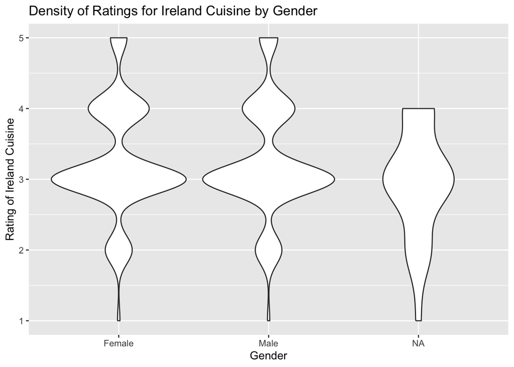

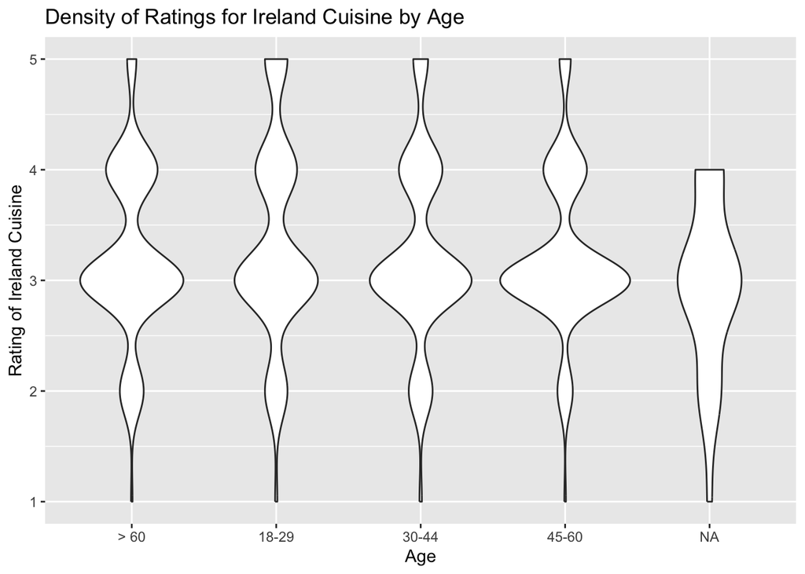

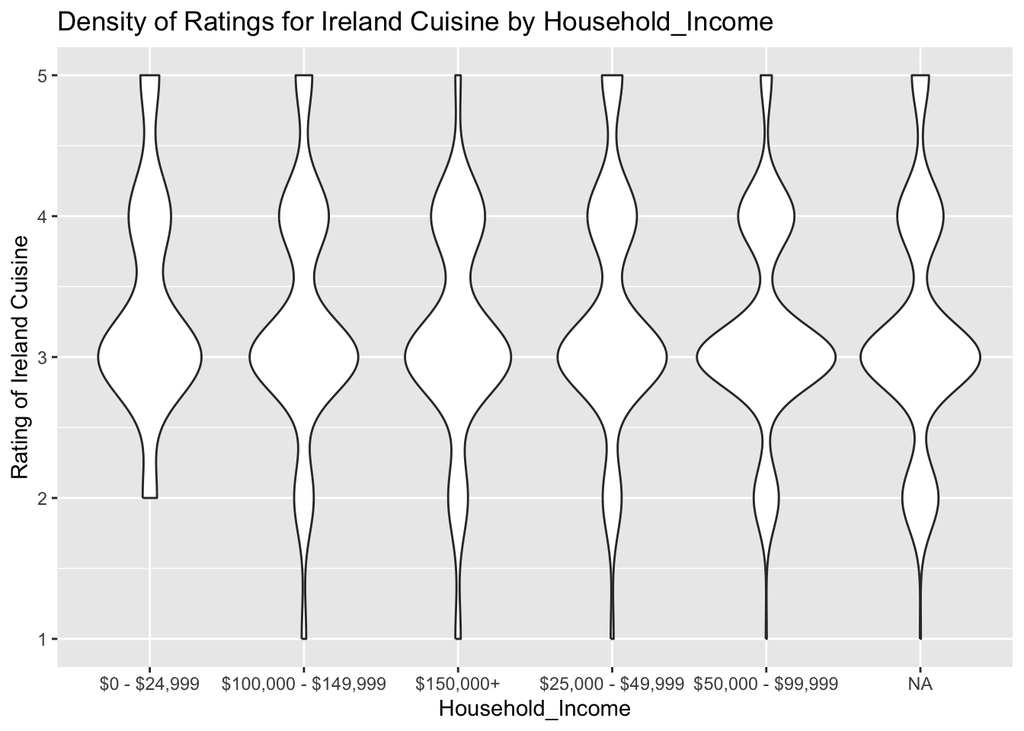

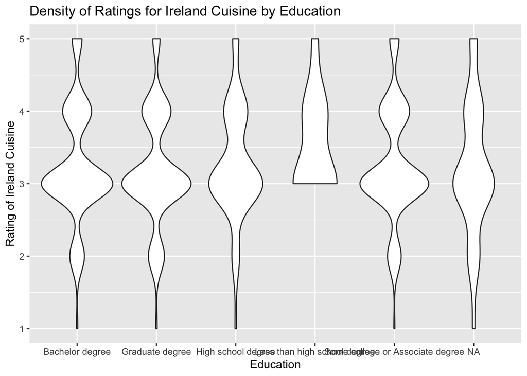

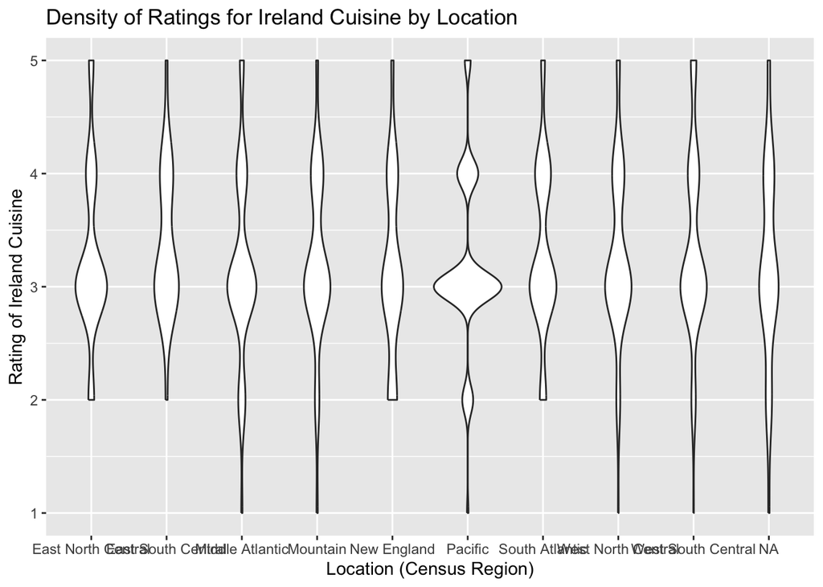

#### While there were some small variation, there is no clear corellation with specifically Irish food. We then did some analysis of our dataset:

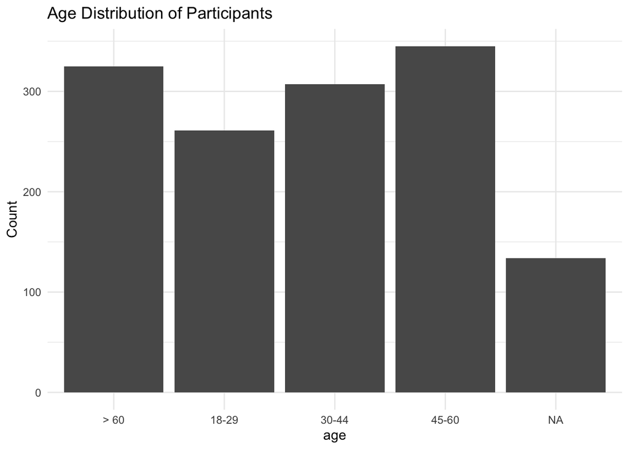

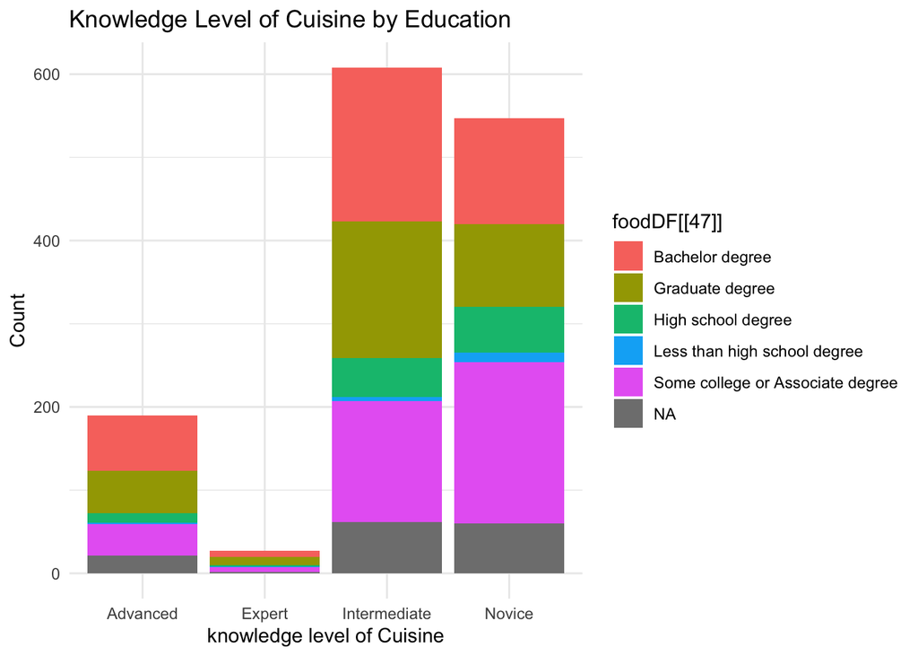

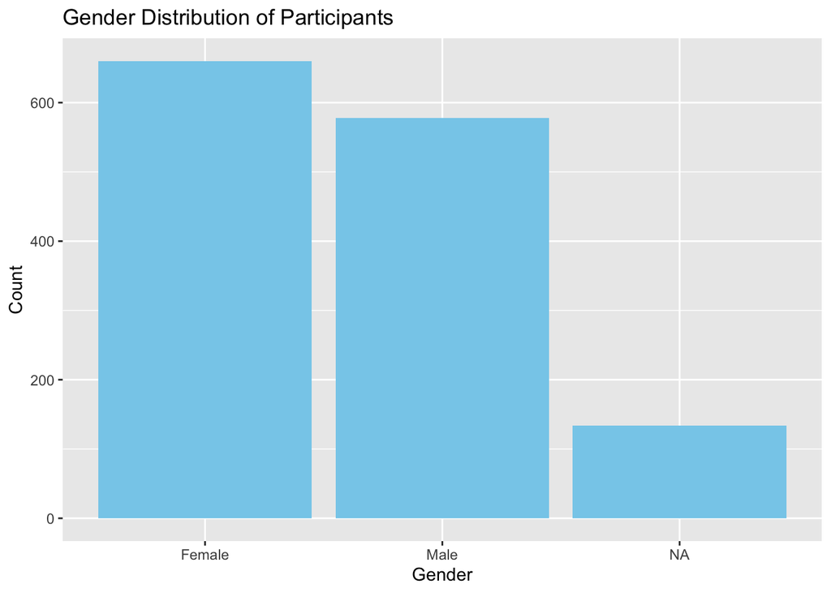

## Methods

#### It would be wasteful to spend time searching each individual country and looking to see if there was any correlation so we created a 3 dimensional graph showing how people of different backgrounds rate different cuisines. These graphs will be reading values of 1-2 as disliking and 4-5 as liking, values of 3 or NA will be removed as we aren’t looking for people that are ok with the food or people that didn’t rate the food. We had to also pivot the dataset to be longer so that each row is one countryrating-person pair instead of one person with all of their country ratings. Then we had to pivot wide once again to differentiate through the different factors. Lastly we made scatter graphs depicting each factor across each different country.

[figure not shown]

[figure not shown]

[figure not shown]

[figure not shown]